# Day 7: Advanced Data Wrangling — In-Class Activity (Solutions)

The Messy Sales Dataset

Instructor

## Setup

```r
sales_data <- tibble(
  order_id = c("ORD-20230115","ORD-20230220","ORD-20230325","ORD-20240410","ORD-20230505",
               "ORD-20230630","ORD-20230712","ORD-20220818","ORD-20230920","ORD-20231105"),
  order_date_str = c("Jan 15, 2023","20/02/2023","2023-03-25","April 10 2024","05-May-2023",
                     "2023-06-30","July 12, 2023","18-Aug-2022","Sep 20, 2023","Nov 5, 2023"),
  shipping_time_str = c("10:30 AM","14:05 PM","12:00 PM","9:15 AM","11:45 AM",
                        NA,"13:30 PM","10:00 AM","15:30 PM","8:45 AM"),
  customer_info = c("John.D-New","Jane_S_Old","Peter_J-New","Maria.L-New","Mike_A_Old",
                    "Sarah.W-New","Sam.T_Old","Emily_R_New","David_K_New","Lisa.M-Old"),
  customer_segment = c("Tier 1","Tier 2","Tier 1","Tier 1","Tier 2",
                       "Tier 1","Tier 2","Tier 1","Tier 1","Tier 2"),
  product_revenue = c(150.75, 200.50, NA, 85.25, -50.00, 45.99, NA, 1250.00, 320.15, 89.99),
  feedback_status = c("Complete","Pending","N/A","Complete","Not provided",
                      "Pending","N/A","Complete","Pending","Complete")
)
```

## Part 1: Dates and Times

### Step 1.1: Parse the order dates

```r
sales <- sales_data %>%
  mutate(clean_date = as_date(parse_date_time(order_date_str,
                                              orders = c("mdy", "dmy", "ymd"))))
```

All ten parse. **Nothing is `NA` and no warning is printed** — which is exactly what makes the next step necessary.

### Step 1.2: Check your work

```r
sales %>% select(order_id, order_date_str, clean_date)
```

```
## # A tibble: 10 × 3
##    order_id     order_date_str clean_date
##    <chr>        <chr>          <date>
##  1 ORD-20230115 Jan 15, 2023   2023-01-15
##  2 ORD-20230220 20/02/2023     2023-02-20
##  3 ORD-20230325 2023-03-25     2023-03-25
##  4 ORD-20240410 April 10 2024  2024-04-10
##  5 ORD-20230505 05-May-2023    2023-05-20
##  6 ORD-20230630 2023-06-30     2023-06-30
##  7 ORD-20230712 July 12, 2023  2023-07-12
##  8 ORD-20220818 18-Aug-2022    2022-08-18
##  9 ORD-20230920 Sep 20, 2023   2023-09-20
## 10 ORD-20231105 Nov 5, 2023    2023-11-05
```

**Row 5 is wrong.** `"05-May-2023"` should be **2023-05-05**, but `parse_date_time()` returned **2023-05-20**.

Why: `"mdy"` is one of the orders you allowed, and it happens to fit this string. Under `"mdy"`, R reads the leading `05` as the **month**, skips over `May` as if it were a separator, then takes `20` as the day and `23` as a two-digit year. You can check this with `guess_formats("05-May-2023", "mdy")`, which returns `"%m-May-%d%y"`. The month name plays no part in it — `"05-Jun-2023"` also becomes 2023-05-20.

The important part is not the mechanism. It is that **the answer is wrong, the column is complete, and nothing warned you.** A missing-value check would pass. A row count would pass. Only reading the values catches it.

### Step 1.3: Fix the broken row

**Option A: patch the one bad value.**

```r
sales %>%
  mutate(clean_date = if_else(order_date_str == "05-May-2023",
                              dmy("05-May-2023"),
                              clean_date)) %>%
  select(order_date_str, clean_date) %>%
  slice(5)
```

```
## # A tibble: 1 × 2
##   order_date_str clean_date
##   <chr>          <date>
## 1 05-May-2023    2023-05-05
```

`dmy()` has only one format to try, so it reads `05` as the day and gets **2023-05-05**. This works, but it only fixes the row you happened to notice. A new row like `"07-Jun-2023"` would break in exactly the same way.

**Option B: parse each string according to its shape.**

Look at how each string *starts*, and pick the parser that fits that layout:

- starts with four digits (`2023-03-25`) → year first → `ymd()`
- starts with a letter (`Jan 15, 2023`, `April 10 2024`) → month first → `mdy()`
- anything else (`20/02/2023`, `05-May-2023`) → day first → `dmy()`

```r
sales <- sales %>%
  mutate(clean_date = case_when(
    str_detect(order_date_str, "^\\d{4}")   ~ ymd(order_date_str, quiet = TRUE),
    str_detect(order_date_str, "^[A-Za-z]") ~ mdy(order_date_str, quiet = TRUE),
    TRUE                                    ~ dmy(order_date_str, quiet = TRUE)
  ))

sales %>% select(order_date_str, clean_date)
```

```
## # A tibble: 10 × 2
##    order_date_str clean_date
##    <chr>          <date>
##  1 Jan 15, 2023   2023-01-15
##  2 20/02/2023     2023-02-20
##  3 2023-03-25     2023-03-25
##  4 April 10 2024  2024-04-10
##  5 05-May-2023    2023-05-05
##  6 2023-06-30     2023-06-30
##  7 July 12, 2023  2023-07-12
##  8 18-Aug-2022    2022-08-18
##  9 Sep 20, 2023   2023-09-20
## 10 Nov 5, 2023    2023-11-05
```

All ten are now correct, and the rule would also cover the next `"07-Jun-2023"`. (`quiet = TRUE` is needed because `case_when()` runs every parser on every row and then keeps only the result that matches. Without it, `ymd()` would warn about the rows it was never meant to handle.)

Why not just reorder the formats to `orders = c("dmy", "mdy", "ymd")`? Try it — row 5 is **still** 2023-05-20. `parse_date_time()` doesn’t simply try the formats in the order you list them. It builds candidate formats from every order you allow and picks the ones that best fit the whole column. If a wrong format fits the string, the wrong format can win. Option B works because it takes that choice away from the parser: you decide which format each row uses.

*How would you find it in ten thousand rows?* Not by reading. You need a second record of the same fact to check against — and this dataset has one, which Step 2.3 uses.

### Step 1.4: Shipping times

```r
# 1. 12-hour clock only
sales <- sales %>%
  mutate(ship_strict = parse_date_time(shipping_time_str, orders = "IMp"))

# 2. also allow a 24-hour clock
sales <- sales %>%
  mutate(ship_time = parse_date_time(shipping_time_str, orders = c("IMp", "HM")))

sales %>%
  mutate(impossible = str_detect(shipping_time_str, "PM") &
                      as.integer(str_extract(shipping_time_str, "^\\d+")) > 12) %>%
  select(shipping_time_str, ship_strict, ship_time, impossible)
```

```
## # A tibble: 10 × 4
##    shipping_time_str ship_strict         ship_time           impossible
##    <chr>             <dttm>              <dttm>              <lgl>
##  1 10:30 AM          0000-01-01 10:30:00 0000-01-01 10:30:00 FALSE
##  2 14:05 PM          NA                  0000-01-01 14:05:00 TRUE
##  3 12:00 PM          0000-01-01 12:00:00 0000-01-01 12:00:00 FALSE
##  4 9:15 AM           0000-01-01 09:15:00 0000-01-01 09:15:00 FALSE
##  5 11:45 AM          0000-01-01 11:45:00 0000-01-01 11:45:00 FALSE
##  6 <NA>              NA                  NA                  NA
##  7 13:30 PM          NA                  0000-01-01 13:30:00 TRUE
##  8 10:00 AM          0000-01-01 10:00:00 0000-01-01 10:00:00 FALSE
##  9 15:30 PM          NA                  0000-01-01 15:30:00 TRUE
## 10 8:45 AM           0000-01-01 08:45:00 0000-01-01 08:45:00 FALSE
```

**Rows 2, 7 and 9** are impossible: `14:05 PM`, `13:30 PM`, `15:30 PM`. An hour above 12 cannot carry a PM suffix.

*Which version complains?*

- **`orders = "IMp"` complains.** Those three rows become `NA` and R warns `3 failed to parse`. (Row 6 is `NA` too, but it was missing to begin with.)
- **`orders = c("IMp", "HM")` does not.** When `"IMp"` fails, R moves on to `"HM"`, reads the 24-hour number, and ignores the `PM`. You get 14:05, 13:30 and 15:30, with no warning and no `NA`.

So whether R warns you depends on the formats *you* allowed. Allowing more formats means fewer failures, and also fewer warnings. Which behavior is better? The strict version flags the problem, but it replaces three probably-correct times with `NA`. The lenient version keeps sensible values but hides the fact that the data was malformed. A good workflow uses both: parse strictly first to *find* the problems, then decide how to fix them. **Silence is not validation.**

## Part 2: String Manipulation

### Step 2.1: Extract customer status

```r
sales <- sales %>% mutate(customer_status = str_extract(customer_info, "New|Old"))
sales %>% select(customer_info, customer_status)
```

```
## # A tibble: 10 × 2
##    customer_info customer_status
##    <chr>         <chr>
##  1 John.D-New    New
##  2 Jane_S_Old    Old
##  3 Peter_J-New   New
##  4 Maria.L-New   New
##  5 Mike_A_Old    Old
##  6 Sarah.W-New   New
##  7 Sam.T_Old     Old
##  8 Emily_R_New   New
##  9 David_K_New   New
## 10 Lisa.M-Old    Old
```

`|` is alternation: match `New` **or** `Old`. It works regardless of which separator precedes it, which is the point — the separators are inconsistent but the token is not.

### Step 2.2: Clean the customer names

Do it in two steps: first pull out the name, then clean up its separator.

**Step 1: extract the name and initial.**

```r
sales <- sales %>%
  mutate(name_part = str_extract(customer_info, "^[A-Za-z]+[._][A-Za-z]"))

sales %>% select(customer_info, name_part)
```

```
## # A tibble: 10 × 2
##    customer_info name_part
##    <chr>         <chr>
##  1 John.D-New    John.D
##  2 Jane_S_Old    Jane_S
##  3 Peter_J-New   Peter_J
##  4 Maria.L-New   Maria.L
##  5 Mike_A_Old    Mike_A
##  6 Sarah.W-New   Sarah.W
##  7 Sam.T_Old     Sam.T
##  8 Emily_R_New   Emily_R
##  9 David_K_New   David_K
## 10 Lisa.M-Old    Lisa.M
```

Read the pattern left to right:

- `^[A-Za-z]+` is the first name: one or more letters, starting at the beginning of the string (`^`)
- `[._]` is the separator: a dot *or* an underscore
- `[A-Za-z]` is the last initial: exactly one letter

The pattern stops there, so the `-New` / `_Old` at the end is left behind.

**Step 2: replace the separator with a space.**

```r
sales <- sales %>%
  mutate(customer_name = str_replace_all(name_part, "[._]", " "))

sales %>% select(customer_info, name_part, customer_name)
```

```
## # A tibble: 10 × 3
##    customer_info name_part customer_name
##    <chr>         <chr>     <chr>
##  1 John.D-New    John.D    John D
##  2 Jane_S_Old    Jane_S    Jane S
##  3 Peter_J-New   Peter_J   Peter J
##  4 Maria.L-New   Maria.L   Maria L
##  5 Mike_A_Old    Mike_A    Mike A
##  6 Sarah.W-New   Sarah.W   Sarah W
##  7 Sam.T_Old     Sam.T     Sam T
##  8 Emily_R_New   Emily_R   Emily R
##  9 David_K_New   David_K   David K
## 10 Lisa.M-Old    Lisa.M    Lisa M
```

`str_replace_all()` finds every `.` or `_` in `name_part` and replaces it with a space, so `"John.D"` becomes `"John D"`.

Any approach works that produces `"John D"` — `separate()`, `str_sub()`, or `str_split()` are all fine. One caution: if you hard-code character positions with `str_sub()`, ask what happens to a five-letter first name.

### Step 2.3: Pull the date out of the order ID

```r
sales <- sales %>%
  mutate(id_date = ymd(str_extract(order_id, "\\d+")),
         check   = clean_date == id_date)

sales %>% select(order_id, order_date_str, clean_date, id_date, check)
```

```
## # A tibble: 10 × 5
##    order_id     order_date_str clean_date id_date    check
##    <chr>        <chr>          <date>     <date>     <lgl>
##  1 ORD-20230115 Jan 15, 2023   2023-01-15 2023-01-15 TRUE
##  2 ORD-20230220 20/02/2023     2023-02-20 2023-02-20 TRUE
##  3 ORD-20230325 2023-03-25     2023-03-25 2023-03-25 TRUE
##  4 ORD-20240410 April 10 2024  2024-04-10 2024-04-10 TRUE
##  5 ORD-20230505 05-May-2023    2023-05-05 2023-05-05 TRUE
##  6 ORD-20230630 2023-06-30     2023-06-30 2023-06-30 TRUE
##  7 ORD-20230712 July 12, 2023  2023-07-12 2023-07-12 TRUE
##  8 ORD-20220818 18-Aug-2022    2022-08-18 2022-08-18 TRUE
##  9 ORD-20230920 Sep 20, 2023   2023-09-20 2023-09-20 TRUE
## 10 ORD-20231105 Nov 5, 2023    2023-11-05 2023-11-05 TRUE
```

*Do they all match now?* **Yes — all ten**, because you fixed row 5 in Step 1.3.

*Would this have found the broken row by itself?* **Yes.** Before the fix, row 5 had `clean_date` = 2023-05-20 and `id_date` = 2023-05-05, so `check` would have been `FALSE` there and only there. `filter(!check)` would have pointed straight at it, whether the data had ten rows or ten thousand. That is the answer to the question from Step 1.3: **check against a second, independent record of the same fact.**

*Which version would you use from here on?* **`id_date`.** It comes from one fixed format (`YYYYMMDD`), so there is nothing for a parser to guess. When a clean encoding exists, use it, and treat the messy column as something to check against it.

## Part 3: Missing Values

### Step 3.1: Find the disguised missings

```r
sales <- sales %>%
  mutate(feedback_clean = na_if(na_if(feedback_status, "N/A"), "Not provided"))

sales %>% count(feedback_status, feedback_clean)
```

```
## # A tibble: 4 × 3
##   feedback_status feedback_clean     n
##   <chr>           <chr>          <int>
## 1 Complete        Complete           4
## 2 N/A             <NA>               2
## 3 Not provided    <NA>               1
## 4 Pending         Pending            3
```

Two disguises: **`"N/A"`** (2 rows) and **`"Not provided"`** (1 row). After `na_if()` there are **3 real `NA`s**. Nested calls because `na_if()` handles one value at a time.

Before the conversion, `sum(is.na(feedback_status))` is **0** — R saw three ordinary strings, and `count()` reported them as real categories.

### Step 3.2: A negative revenue

```r
c(with_refund    = mean(sales$product_revenue, na.rm = TRUE),
  without_refund = mean(sales$product_revenue[sales$product_revenue >= 0], na.rm = TRUE))
```

```
##    with_refund without_refund
##       261.5788       306.0900
```

**261.58 with it, 306.09 without** — a 17% swing on one row of ten.

There is no single right answer. What matters is naming the possibilities and choosing a defensible action:

- **A real refund** — legitimate, keep it, and say the mean is net of refunds.
- **A data-entry error** (sign flipped on 50.00) — investigate, correct if you can.
- **A sentinel** for “unknown” — convert to `NA`.

What matters is that the decision is **stated**, not which option you pick. “Delete it silently” is the only wrong answer.

### Step 3.3: Visualize what’s missing

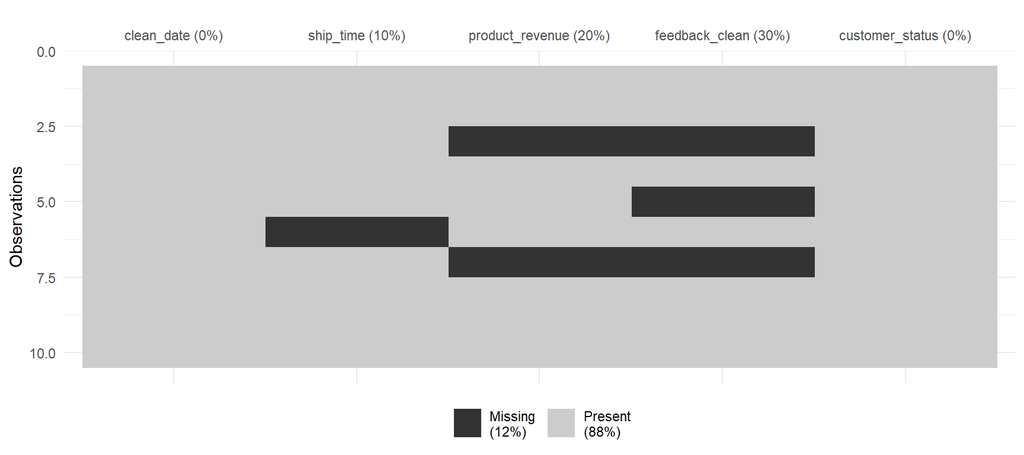

```r
sales %>%
  select(clean_date, ship_time, product_revenue, feedback_clean, customer_status) %>%
  vis_miss() +
  theme(axis.text.x.top = element_text(angle = 0, hjust = 0.5))  # horizontal column labels
```

Three columns carry gaps: `ship_time` (1), `product_revenue` (2) and `feedback_clean` (3). Note that `feedback_clean` shows missing only *because* of Step 3.1 — run `vis_miss()` on the raw column and it looks complete.

### Step 3.4: Impute by group

```r
sales <- sales %>%
  group_by(customer_segment) %>%
  mutate(revenue_filled = if_else(is.na(product_revenue),
                                  mean(product_revenue, na.rm = TRUE),
                                  product_revenue))

sales %>%
  select(customer_segment, product_revenue, revenue_filled) %>%
  mutate(invented = is.na(product_revenue))
```

```
## # A tibble: 10 × 4
## # Groups:   customer_segment [2]
##    customer_segment product_revenue revenue_filled invented
##    <chr>                      <dbl>          <dbl> <lgl>
##  1 Tier 1                     151.           151.  FALSE
##  2 Tier 2                     200.           200.  FALSE
##  3 Tier 1                      NA            370.  TRUE
##  4 Tier 1                      85.2           85.2 FALSE
##  5 Tier 2                     -50            -50   FALSE
##  6 Tier 1                      46.0           46.0 FALSE
##  7 Tier 2                      NA             80.2 TRUE
##  8 Tier 1                    1250           1250   FALSE
##  9 Tier 1                     320.           320.  FALSE
## 10 Tier 2                      90.0           90.0 FALSE
```

Segment means: **Tier 1 = 370.43**, **Tier 2 = 80.16**. So row 3 is filled with 370.43 and row 7 with 80.16.

*How many rows did you invent numbers for?* **2 of 10 — 20% of the column.**

Notice that Tier 2’s mean of **80.16 includes the −50 refund** from Step 3.2. Whatever you decided — or avoided deciding — there has now been multiplied into a value that gets reported as data. An unresolved decision does not stay put.

## Wrap-up & Discussion

**1. Silent parsing errors — how common, and what habit catches them?**

More common than anyone admits, because nothing surfaces them: the column is complete, the types are right, the code runs. The habit is to **look at the values after every parse**, and better, to **check against a second source** when one exists. Here the second source was free — `order_id` carried the same date.

**2. When is redundancy worth the effort?**

When the cost of being silently wrong is high, and when a second source already exists. Nobody builds redundancy for its own sake; the point is to *notice* it when it is sitting there.

Follow that to its conclusion here: because `order_id` carries the date, `order_date_str` was never needed at all. `str_extract()` plus `ymd()` gives ten correct dates with no parser to second-guess. When a clean encoding exists, use it. The messy column earned its place in this activity only because it let you *watch* a parser be confidently wrong — in most datasets the ugly string is the only copy, and then there is nothing to check it against.

The other half of the answer names a case where redundancy buys nothing: two columns fed by the same upstream system check nothing, because they would be wrong together.

**3. 20% of the revenue column is fabricated. What should a reader be told?**

How many values were imputed, which ones, by what method, and what changes if they are excluded instead. Ideally keep the `invented` flag in the data so the analysis can be run both ways. The unacceptable version is a table of means with no indication that a fifth of the inputs were manufactured.

**4. Which was more dangerous: the obvious `NA`s or the plausible values?**

**The plausible ones**, and the whole activity is built to make that land. An `NA` announces itself — every summary function reports it. `-50.00`, `"14:05 PM"` and the 2023-05-20 date all pass silently through code that is looking for missingness. The data *looks* clean, which is worse than looking broken.

## Challenge

### C1: Combine date and time, then elapsed time

```r
sales <- sales %>%
  mutate(order_timestamp = ymd_hm(paste(clean_date, format(ship_time, "%H:%M"))))

sales %>% select(clean_date, shipping_time_str, order_timestamp)
```

```
## # A tibble: 10 × 4
## # Groups:   customer_segment [2]
##    customer_segment clean_date shipping_time_str order_timestamp
##    <chr>            <date>     <chr>             <dttm>
##  1 Tier 1           2023-01-15 10:30 AM          2023-01-15 10:30:00
##  2 Tier 2           2023-02-20 14:05 PM          2023-02-20 14:05:00
##  3 Tier 1           2023-03-25 12:00 PM          2023-03-25 12:00:00
##  4 Tier 1           2024-04-10 9:15 AM           2024-04-10 09:15:00
##  5 Tier 2           2023-05-05 11:45 AM          2023-05-05 11:45:00
##  6 Tier 1           2023-06-30 <NA>              NA
##  7 Tier 2           2023-07-12 13:30 PM          2023-07-12 13:30:00
##  8 Tier 1           2022-08-18 10:00 AM          2022-08-18 10:00:00
##  9 Tier 1           2023-09-20 15:30 PM          2023-09-20 15:30:00
## 10 Tier 2           2023-11-05 8:45 AM           2023-11-05 08:45:00
```

```r
first_order <- min(sales$order_timestamp, na.rm = TRUE)
last_order  <- max(sales$order_timestamp, na.rm = TRUE)
difftime(last_order, first_order, units = "days")
```

```
## Time difference of 600.9688 days
```

`format(ship_time, "%H:%M")` turns the parsed time back into text like `"14:05"`. Pasting it after the date gives `"2023-02-20 14:05"`, which `ymd_hm()` parses.

First order **2022-08-18 10:00**, last **2024-04-10 09:15**. Setting `units = "days"` matters: a bare `last_order - first_order` lets R pick the units.

*What happened to the missing and impossible times?*

- **Row 6** has no shipping time, so its timestamp is `NA`. `na.rm = TRUE` drops it from `min()` and `max()`. It happens not to be the first or last order, but if it were, the span would be silently wrong.
- **Rows 2, 7 and 9** got 14:05, 13:30 and 15:30, the lenient parse from Step 1.4. They are now full timestamps that look exactly as trustworthy as the others. Nothing in `order_timestamp` records that they came from malformed input. Carrying an `impossible` flag forward is how you keep that information.

### C2: Validate the order ID format

```r
sum(str_detect(sales$order_id, "^ORD-\\d{8}$"))
```

```
## [1] 10
```

**All ten pass.** `^` anchors the start, `\\d{8}` is exactly eight digits, `$` anchors the end. Without the anchors, `ORD-2023011500000` would also match — worth asking why they matter.

### C3: Orders by weekday

```r
sales %>%
  ungroup() %>%
  count(weekday = wday(clean_date, label = TRUE), .drop = FALSE)
```

```
## # A tibble: 7 × 2
##   weekday     n
##   <ord>   <int>
## 1 Sun         2
## 2 Mon         1
## 3 Tue         0
## 4 Wed         3
## 5 Thu         1
## 6 Fri         2
## 7 Sat         1
```

Wednesday 3, Sunday 2, Friday 2, Monday 1, Thursday 1, Saturday 1, Tuesday 0.

*Check the grouping.* `sales` is still grouped by `customer_segment` from Step 3.4. Without the `ungroup()`, `count()` would keep that grouping and count by segment *and* weekday, without any warning. To check, print `sales` and look for a `# Groups:` line, or run `group_vars(sales)`.